# COMP 162 Project 1

Christine Rease

2026-03-01

```r
# Load in data
library(tidyverse)
sleepdata <- read.csv("sleepdata.csv")
```

# Introduction

### Link to *Sleep Efficiency Dataset*

https://www.kaggle.com/datasets/equilibriumm/sleep-efficiency

### Description of Dataset

> “The dataset contains information about a group of test subjects and their sleep patterns. Each test subject is identified by a unique”Subject ID” and their age and gender are also recorded. The “Bedtime” and “Wakeup time” features indicate when each subject goes to bed and wakes up each day, and the “Sleep duration” feature records the total amount of time each subject slept in hours. The “Sleep efficiency” feature is a measure of the proportion of time spent in bed that is actually spent asleep. The “REM sleep percentage”, “Deep sleep percentage”, and “Light sleep percentage” features indicate the amount of time each subject spent in each stage of sleep. The “Awakenings” feature records the number of times each subject wakes up during the night. Additionally, the dataset includes information about each subject’s caffeine and alcohol consumption in the 24 hours prior to bedtime, their smoking status, and their exercise frequency.”

-Equilibriumm, *Kaggle*

These are the included variables:

- ID - a unique identifier for each test subject
- Age - age of the test subject
- Gender - male or female
- Bedtime - the time the test subject goes to bed each night
- Wakeup.time - the time the test subject wakes up each morning
- Sleep.duration - the total amount of time the test subject slept (in hours)
- Sleep.efficiency - a measure of the proportion of time in bed spent asleep
- REM.sleep.percentage - the percentage of total sleep time spent in REM sleep
- Deep.sleep.percentage - the percentage of total sleep time spent in deep sleep
- Light.sleep.percentage - the percentage of total sleep time spent in light sleep
- Awakenings - the number of times the test subject wakes up during the night
- Alcohol.consumption - the amount of alcohol in oz consumed in the 24 hours prior to bedtime
- Smoking.status - whether or not the test subject smokes
- Exercise.frequency - the number of times the test subject exercises each week

### Motivation

Sleep is an important factor that affects both physical and mental health. I chose this dataset because it seemed interesting to me, and I wanted to see whether patterns similar to my own sleep habits could be observed in the data.

### Summary Statistics

```r
summary(sleepdata)
```

```
##        X                ID             Age           Gender
##  Min.   :  1.00   Min.   :  1.0   Min.   : 9.00   Length:388
##  1st Qu.: 97.75   1st Qu.:111.8   1st Qu.:29.00   Class :character
##  Median :194.50   Median :228.5   Median :41.00   Mode  :character
##  Mean   :194.50   Mean   :226.3   Mean   :40.83
##  3rd Qu.:291.25   3rd Qu.:339.2   3rd Qu.:52.00
##  Max.   :388.00   Max.   :452.0   Max.   :69.00
##    Bedtime          Wakeup.time        Sleep.duration   Sleep.efficiency
##  Length:388         Length:388         Min.   : 5.000   Min.   :0.5000
##  Class :character   Class :character   1st Qu.: 7.000   1st Qu.:0.7000
##  Mode  :character   Mode  :character   Median : 7.500   Median :0.8200
##                                        Mean   : 7.451   Mean   :0.7893
##                                        3rd Qu.: 8.000   3rd Qu.:0.9000
##                                        Max.   :10.000   Max.   :0.9900
##  REM.sleep.percentage Deep.sleep.percentage Light.sleep.percentage
##  Min.   :15.00        Min.   :18.00         Min.   : 7.0
##  1st Qu.:20.00        1st Qu.:51.00         1st Qu.:15.0
##  Median :22.00        Median :58.00         Median :18.0
##  Mean   :22.68        Mean   :52.82         Mean   :24.5
##  3rd Qu.:25.00        3rd Qu.:63.00         3rd Qu.:24.0
##  Max.   :30.00        Max.   :75.00         Max.   :63.0
##    Awakenings    Caffeine.consumption Alcohol.consumption Smoking.status
##  Min.   :0.000   Min.   :  0.00       Min.   :0.000       Length:388
##  1st Qu.:1.000   1st Qu.:  0.00       1st Qu.:0.000       Class :character
##  Median :1.000   Median :  0.00       Median :0.000       Mode  :character
##  Mean   :1.619   Mean   : 22.68       Mean   :1.147
##  3rd Qu.:3.000   3rd Qu.: 50.00       3rd Qu.:2.000
##  Max.   :4.000   Max.   :200.00       Max.   :5.000
##  Exercise.frequency
##  Min.   :0.000
##  1st Qu.:0.000
##  Median :2.000
##  Mean   :1.758
##  3rd Qu.:3.000
##  Max.   :5.000
```

The summary statistics provide an overview of the dataset, including the minimum, maximum, median, and mean values for each quantitative variable.

# Visualizations

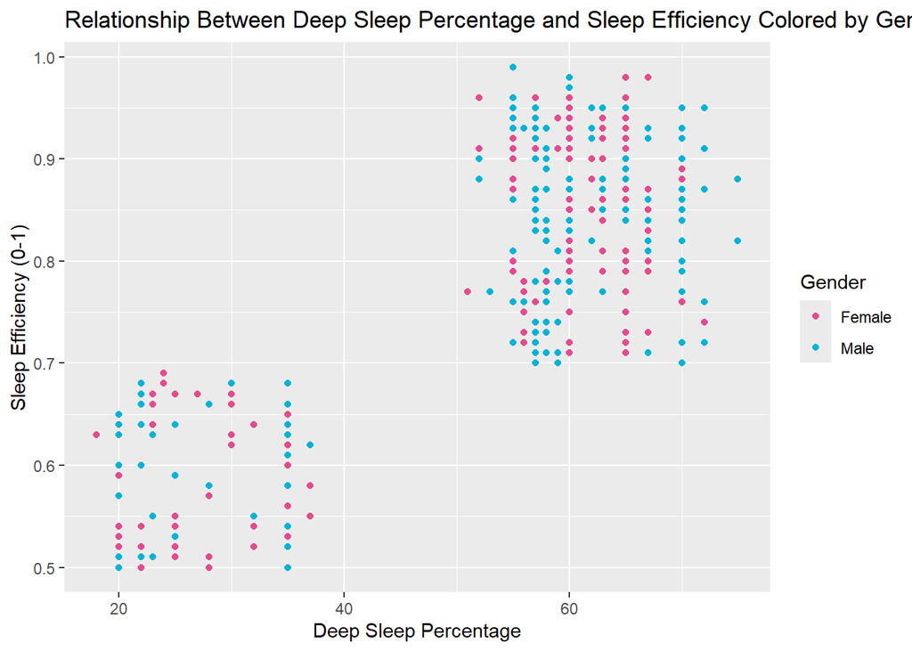

```r
sleepdata %>%
  ggplot(aes(x = Deep.sleep.percentage,
             y = Sleep.efficiency)) +
  geom_point(aes(color = Gender)) +
  labs(
    title = "Relationship Between Deep Sleep Percentage and Sleep Efficiency Colored by Gender",
    x = "Deep Sleep Percentage",
    y = "Sleep Efficiency (0-1)"
  ) +
  scale_color_manual(values = c("Female" = "#e44b8d", "Male" = "#00b4d8"))
```

The scatterplot shows a relationship between the proportion of time spent in deep sleep and overall sleep efficiency. Each point is also colored by the subject’s gender. From the plot, we can see a slight positive trend, suggesting that individuals who spend a higher percentage of their sleep in deep sleep tend to have a higher sleep efficiency, which makes sense because deep sleep is restorative and contributes to more effective sleep. Also, the plot shows that both men and women are distributed across similar ranges of deep sleep and efficiency, which indicates that gender alone doesn’t appear to create major differences in this relationship.

### Smoking vs Age

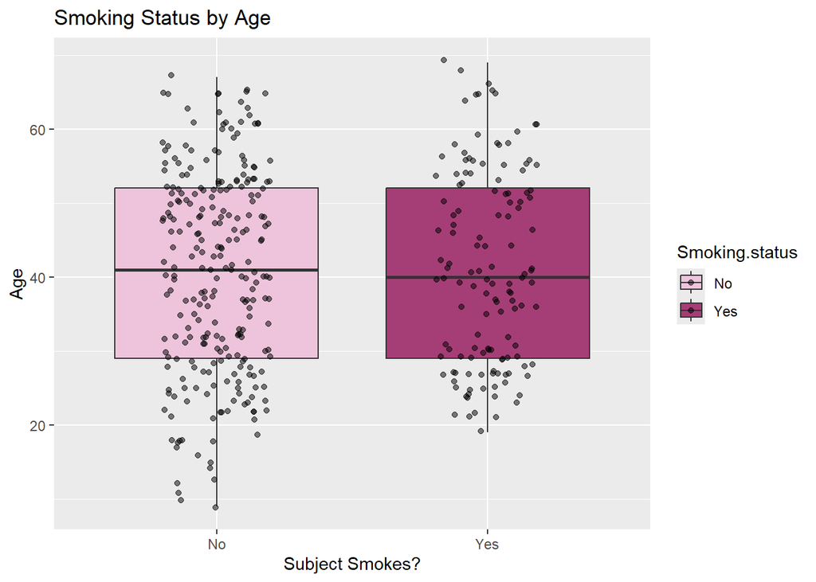

```r
sleepdata %>%
  ggplot(aes(x = Smoking.status,
             y = Age,
             fill = Smoking.status)) +
  geom_boxplot() +
  labs(
    title = "Smoking Status by Age",
    x = "Subject Smokes?",
    y = "Age"
  ) +
  scale_fill_manual(values = c("No" = "#eec4dc", "Yes" = "#a53e76")) +
  geom_jitter(width = 0.2, alpha = 0.5)
```

This boxplot compares smoking status by age. Age distributions for smokers and non-smokers are seemingly similar, with overlapping ranges and medians around 40 years. Smokers show slightly more older participants, but overall, age alone doesn’t clearly distinguish smoking status.

# Dataset Manipulations

### Exercise Frequency and Sleep Duration

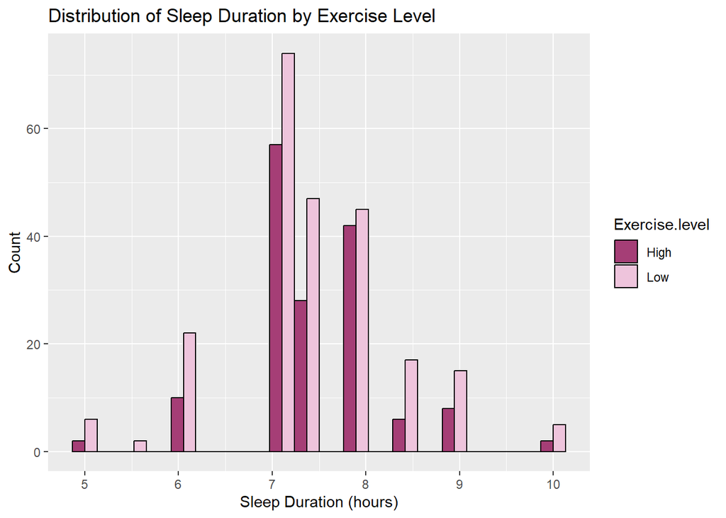

```r
# Add Exercise.level to dataset
sleepdata <- sleepdata %>%
  mutate(Exercise.level = ifelse(Exercise.frequency >= 3, "High", "Low"))

# Plot using new Exercise.level column
sleepdata %>%
  ggplot(aes(x = Sleep.duration, fill = Exercise.level)) +
  geom_histogram(position = "dodge", bins = 20, color = "black") +
  labs(
    title = "Distribution of Sleep Duration by Exercise Level",
    x = "Sleep Duration (hours)",
    y = "Count"
  ) +
  scale_fill_manual(values = c("Low" = "#eec4dc", "High" = "#a53e76"))
```

To explore how lifestyle affects sleep, I created a new variable called *Exercise.level* from the *Exercise.frequency* column. Subjects who exercise 3 or more times per week were labeled as “High”, and those who were less than 3 times per week were labeled as “Low”. I then plotted the distribution of sleep duration by exercise level. This manipulation reveals that most individuals, regardless of exercise level, sleep around 7-8 hours a night. Those in the **High** exercise group tend to have slightly more consistent sleep, while the **Low** group shows a wider spread into longer durations. This suggests that higher exercise frequency may be associated with more regular sleep patterns.

# Statistical Analyses

### Light Sleep Percentage vs Sleep Efficiency

```r
cor(sleepdata$Light.sleep.percentage, sleepdata$Sleep.efficiency)
```

```
## [1] -0.8169342
```

There is a strong negative correlation between light sleep percentage and sleep efficiency, which indicates that higher proportions of light sleep are associated with lower sleep efficiency.

### Light Sleep Predicting Sleep Efficiency

```r
lm_sleep <- lm(Sleep.efficiency ~ Light.sleep.percentage, data = sleepdata)
summary(lm_sleep)
```

```
##
## Call:
## lm(formula = Sleep.efficiency ~ Light.sleep.percentage, data = sleepdata)
##
## Residuals:
##       Min        1Q    Median        3Q       Max
## -0.179751 -0.066303  0.006973  0.065680  0.153697
##
## Coefficients:
##                          Estimate Std. Error t value Pr(>|t|)
## (Intercept)             0.9666482  0.0075140  128.65   <2e-16 ***
## Light.sleep.percentage -0.0072414  0.0002602  -27.83   <2e-16 ***
## ---
## Signif. codes:  0 '***' 0.001 '**' 0.01 '*' 0.05 '.' 0.1 ' ' 1
##
## Residual standard error: 0.07837 on 386 degrees of freedom
## Multiple R-squared:  0.6674, Adjusted R-squared:  0.6665
## F-statistic: 774.5 on 1 and 386 DF,  p-value: < 2.2e-16
```

The linear regression predicting sleep efficiency from light sleep percentage showed a strong negative relationship (-0.0072414, p < 2.2e-16), which indicates that higher proportions of light sleep are associated with lower sleep efficiency. The model explains 66.74% of the variation in sleep efficiency.

### Smoking Status vs Sleep Efficiency

```r
t.test(Sleep.efficiency ~ Smoking.status, data = sleepdata)
```

```
##
##  Welch Two Sample t-test
##
## data:  Sleep.efficiency by Smoking.status
## t = 5.3891, df = 200.24, p-value = 1.979e-07
## alternative hypothesis: true difference in means between group No and group Yes is not equal to 0
## 95 percent confidence interval:
##  0.05303355 0.11423816
## sample estimates:
##  mean in group No mean in group Yes
##         0.8179216         0.7342857
```

The t-test showed that non-smokers have significantly higher sleep efficiency than smokers (mean = 0.8179216 vs 0.7342857, t = 5.389, p < 1.979e-07, 95% Confidence Interval [0.05303355, 0.11423816]).

# Conclusion

### Relationship Between Deep Sleep Percentage and Sleep Efficiency

The scatterplot showed that participants with higher deep sleep percentages tend to have higher sleep efficiency. Gender did not appear to have a strong effect on this relationship.

### Smoking Status vs Age

The boxplot showed that the age distribution sof smokers and non-smokers largely overlap, meaning age alone doesn’t clearly distinguish smoking status.

### Exercise Frequency vs Sleep Duration

Participants who exercise more frequently tend to have slightly more consistent sleep durations. Most participants sleep around 7-8 hours per night, regardless of exercise level.

### Light Sleep Percentage vs Sleep Efficiency

There is a strong negative correlation between light sleep percentage and sleep efficiency. Linear regression showed that higher light sleep significantly predicts lower sleep efficiency, explaining about 67% of the variation.

### Smoking Status vs Sleep Efficiency

Non-smokers had a significantly higher sleep efficiency than smokers, with a mean difference of about 0.084, meaning smoking is associated with lower sleep efficiency.

## **All in All…**

Participants with higher deep sleep percentages tend to have higher sleep efficiency, while gender doesn’t seem to influence this relationship. Age does not clearly distinguish smokers from non-smokers, but non-smoker have significantly higher sleep efficiency than smokers. Higher exercise frequency is associated with slightly more consistent sleep durations, although most participants sleep for around 7-8 hours per night. Light sleep percentage is strongly negatively correlated with sleep efficiency, with higher light sleep predicting lower efficiency and explaining about 67% of its variation. Overall, sleep stage composition and smoking status are the strongest factors that I found influencing sleep quality.